# FA Homework - 3 Report

# ——————————————————————

# Question 4 — Annual rebalancing of FW portfolios (January weights held through year)

```python
# We'll reuse top1000 frame, but ensure it has sale2price_lag and BE_ME_lag
top1000 = top1000.sort_values(['permno','date']).reset_index(drop=True)

# Keep only needed columns and ensure unique month index
top1000['year'] = top1000['date'].dt.year
top1000['month'] = top1000['date'].dt.month

# Annual weights for sale2price: compute w in January rows and forward-fill within year
weights_sp = (
    top1000[top1000['month'] == 1]
    .dropna(subset=['sale2price_lag'])
    .groupby('date')
    .apply(lambda df: df.assign(w = df['sale2price_lag'] / df['sale2price_lag'].sum()))
    .reset_index(drop=True)
)
# Merge w (only January rows) back to top1000 then forward-fill within permno-year
weights_sp_small = weights_sp[['permno','date','w']]
# merge on permno & date (only Jan rows will match)
top1000 = top1000.merge(weights_sp_small, how='left', on=['permno','date'])
# forward fill w within each permno-year
top1000['w_sp_ann'] = top1000.groupby(['permno','year'])['w'].ffill()
top1000.drop(columns=['w'], inplace=True, errors='ignore')

# Compute monthly returns for annual-FW by sale2price
top1000['w_sp_ann_ret'] = top1000['w_sp_ann'] * top1000['ret']
Portfolio_ann_sp = top1000.groupby('date').agg(fw_sp_ann_ret=('w_sp_ann_ret','sum')).reset_index()

# Now do BE/ME annual weights similarly
weights_be = (
    top1000[top1000['month'] == 1]
    .dropna(subset=['BE_ME_lag'])
    .groupby('date')
    .apply(lambda df: df.assign(w = df['BE_ME_lag'] / df['BE_ME_lag'].sum()))
    .reset_index(drop=True)
)
weights_be_small = weights_be[['permno','date','w']]
top1000 = top1000.merge(weights_be_small, how='left', on=['permno','date'], suffixes=('','_be'))
top1000['w_bp_ann'] = top1000.groupby(['permno','year'])['w'].ffill()
top1000.drop(columns=['w'], inplace=True, errors='ignore')

top1000['w_bp_ann_ret'] = top1000['w_bp_ann'] * top1000['ret']
Portfolio_ann_bp = top1000.groupby('date').agg(fw_bp_ann_ret=('w_bp_ann_ret','sum')).reset_index()

# Combine annual FW returns into ann_df
ann_df = Portfolio_ann_sp.merge(Portfolio_ann_bp, on='date', how='outer').sort_values('date').reset_index(drop=True)
ann_df.head()
```

|  | date | fw_sp_ann_ret | fw_bp_ann_ret |
| --- | --- | --- | --- |
| 0 | 1979-12-31 | 0.000000 | 0.000000 |
| 1 | 1980-01-31 | 7.056934 | 5.763726 |
| 2 | 1980-02-29 | -3.395401 | -3.310002 |
| 3 | 1980-03-31 | -12.179071 | -11.178458 |
| 4 | 1980-04-30 | 5.493286 | 6.552626 |

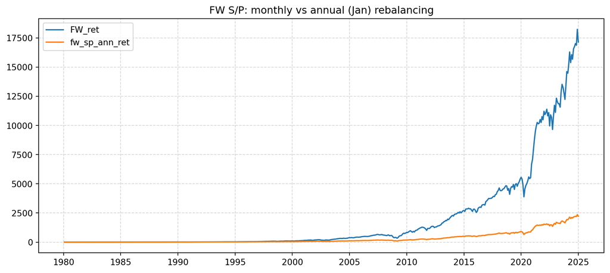

```python
# Compare cumulative monthly-FW vs annual-FW (S/P example)
# For monthly FW we need FW_ret series from Portfolios (FW_ret column)
monthly_fw_sp = Portfolios[['date','FW_ret']].dropna()
ann_comp = monthly_fw_sp.merge(ann_df[['date','fw_sp_ann_ret']], on='date', how='left')

ann_comp_long = ann_comp.melt(id_vars='date', var_name='Strategy', value_name='Return')
ann_comp_long['ret_plus1'] = 1 + ann_comp_long['Return']/100.0
ann_comp_long['cumRet'] = ann_comp_long.groupby('Strategy')['ret_plus1'].cumprod()

plt.figure(figsize=(12,5))
for strat, grp in ann_comp_long.groupby('Strategy'):
    plt.plot(grp['date'], grp['cumRet'], label=strat)
plt.title('FW S/P: monthly vs annual (Jan) rebalancing')
plt.legend()
plt.grid(True, linestyle='--', alpha=0.5)
plt.show()
```

# cont-

Weights drift because prices move after formation: the dollar amount allocated to each stock changes with returns, so the original fundamental proportions no longer hold. Annual rebalancing resets the target weights each January, reducing drift but incurring turnover. The comparison shows annual rebalancing smooths trading but may lag monthly target exposures. The practical choice balances tracking error vs trading costs.

# saving outputs

```python
Portfolios.to_csv('hw3_portfolios_reference.csv', index=False)
Portfolios_long.to_csv('hw3_portfolios_long.csv', index=False)
sumstats.to_csv('hw3_summary_stats.csv', index=False)
ann_df.to_csv('hw3_annual_fw.csv', index=False)
print("Saved CSVs: hw3_portfolios_reference.csv, hw3_portfolios_long.csv, hw3_summary_stats.csv, hw3_annual_fw.csv")
```

```
Saved CSVs: hw3_portfolios_reference.csv, hw3_portfolios_long.csv, hw3_summary_stats.csv, hw3_annual_fw.csv
```